# WorMotel Life Span Heritability

Tim C.

1/17/2018

This code uses processed survival data from Chris Fang-Yen’s lab to calcualte heritability of survival traits. The data were collected with WorMotel in winter 2017 by Matt Churgin at UPenn.

#### Read in data

```r
df <- as.data.frame(read.csv(file = "20170116_FullProcessed.csv", header = T))
glimpse(df)
```

```
## Observations: 64,800
## Variables: 8
## $ strain        <fct> CB4856, CB4856, CB4856, CB4856, CB4856, CB4856, ...
## $ tech_rep      <int> 2, 2, 2, 2, 2, 2, 2, 2, 2, 2, 2, 2, 2, 2, 2, 2, ...
## $ bio_rep       <int> 1, 1, 1, 1, 1, 1, 1, 1, 1, 1, 1, 1, 1, 1, 1, 1, ...
## $ rep           <int> 1, 1, 1, 1, 1, 1, 1, 1, 1, 1, 1, 1, 1, 1, 1, 1, ...
## $ life_span     <dbl> NA, NA, NA, NA, NA, NA, NA, NA, NA, NA, NA, NA, ...
## $ activity_type <fct> stim, stim, stim, stim, stim, stim, stim, stim, ...
## $ time_d        <dbl> 1.5, 3.0, 4.5, 6.0, 8.0, 9.5, 11.5, 13.0, 15.0, ...
## $ activity      <int> 0, 0, 0, 0, 0, 0, 0, 0, 0, 0, 0, 0, 0, 0, 0, 0, ...
```

#### Plot raw data

The survival curves below are broken out by technical and biological replicate. I’m not certain what is meant by technical rep and biological rep. Can we clarify this? For the rest of the analysis I’m going to treat biological reps as blocks.

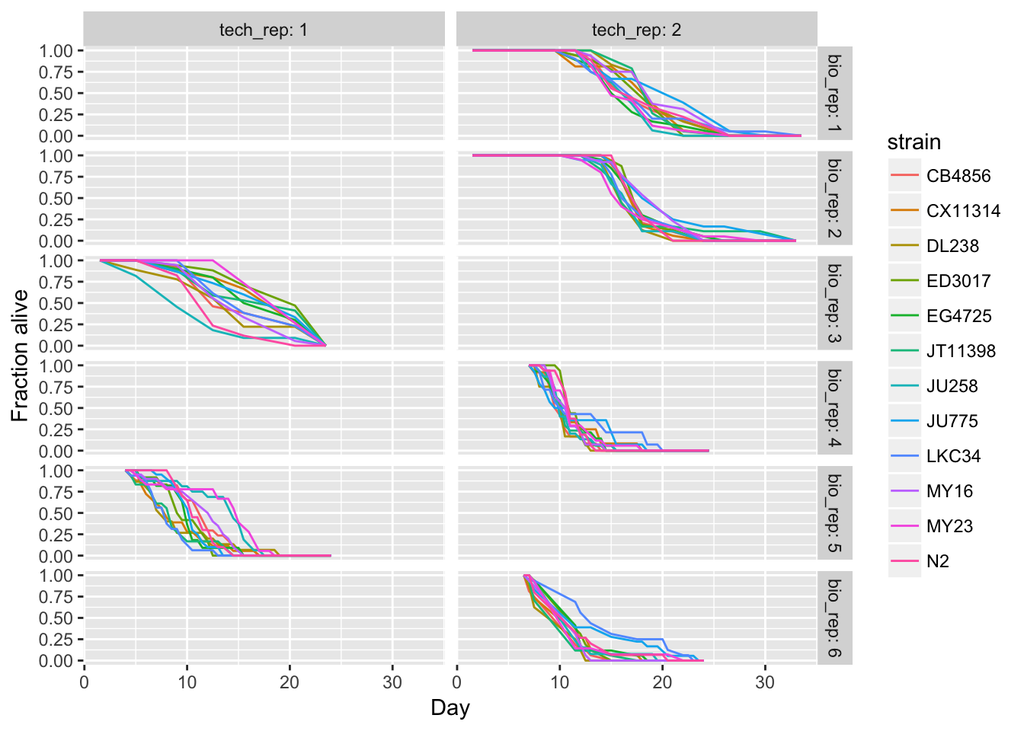

The data looks as expected, but there appears to be large block effects. Next, I’ll fit weibull survival model to the data (two parameter survival model). The traits used for heritability will be the shape and scale parameters from the fit as well as time to 90% survival, time to 50% survival, and time to 10% survival.

####Plotting Weibull survival model parameters

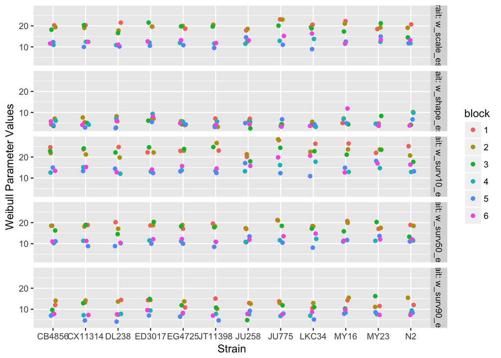

There are very small differences among strains for all traits. This suggests there is low heritability for these traits. It also looks like the block effect is much larger than the effect of strain. We can run a linear mixed model to estimate the relative effects of block vs. strain on each trait.

#### Fit linear mixed model to estimate relative size of block and strain random effects on traits

```
## Linear mixed model fit by REML ['lmerMod']
## Formula: phenotype ~ 1 + (1 | strain) + (1 | block)
##    Data: h_df_gather %>% dplyr::filter(trait == "w_scale_est")
##
## REML criterion at convergence: 304
##
## Scaled residuals:
##     Min      1Q  Median      3Q     Max
## -3.2372 -0.5513 -0.0417  0.5163  1.9890
##
## Random effects:
##  Groups   Name        Variance Std.Dev.
##  strain   (Intercept)  0.189   0.4347
##  block    (Intercept) 16.745   4.0920
##  Residual              2.800   1.6732
## Number of obs: 72, groups:  strain, 12; block, 6
##
## Fixed effects:
##             Estimate Std. Error t value
## (Intercept)   15.790      1.687   9.361
```

The model summary above shows that the block effect is much larger than the strain effect for the weibull scale parameter trait. This pattern is true for all the traits except the weibull shape parameter. The small effect of strain means that we will probably see very low heritability for most traits. It’s possible we’ll see higher heritability for the weibull shape parameter.

#### Calculating heritability for traits

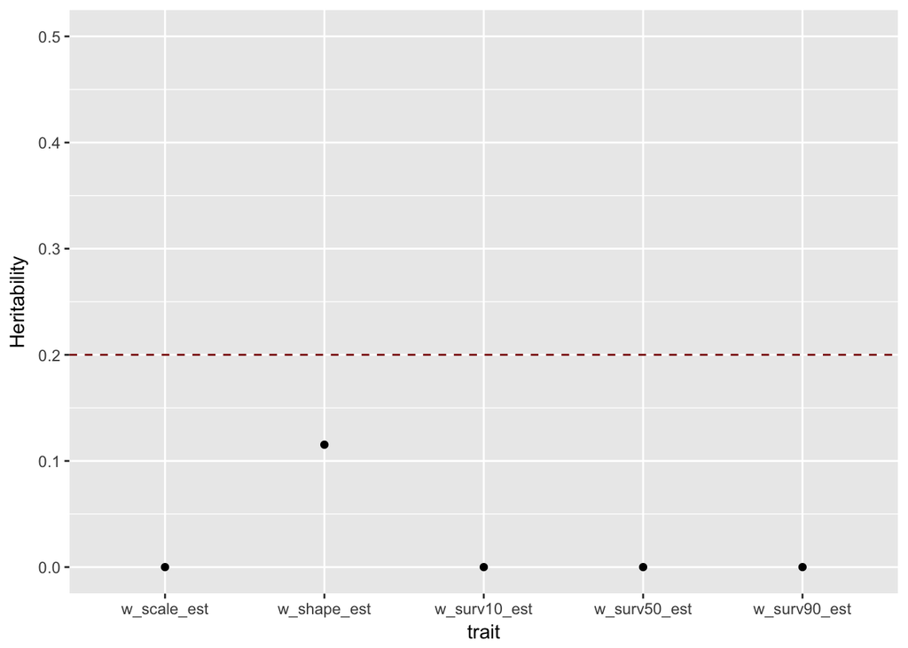

As expected heritability is extremely low for all traits except weibull shape parameter. Even so, the heritability is less that 0.2, which is generally what we like to see before performing a GWA study. We might be able to improve our ability to see heritability by correcting for the large block effect. I’ll try that next.

####Correcting for block effects by fitting linear model phenotype ~ block for each trait, then extracting residual values of trait paramters to use in heritability calculation The structure of the corrected data frame is shown below. Below that is a plot of the corrected traits.

```
## Observations: 360
## Variables: 4
## $ block     <fct> 1, 2, 3, 4, 5, 6, 1, 2, 3, 4, 5, 6, 1, 2, 3, 4, 5, 6...
## $ strain    <fct> CB4856, CB4856, CB4856, CB4856, CB4856, CB4856, CX11...
## $ trait     <chr> "shape_par", "shape_par", "shape_par", "shape_par", ...
## $ phenotype <dbl> -0.86925112, 0.66000652, -0.88603807, 0.15245487, -0...
```

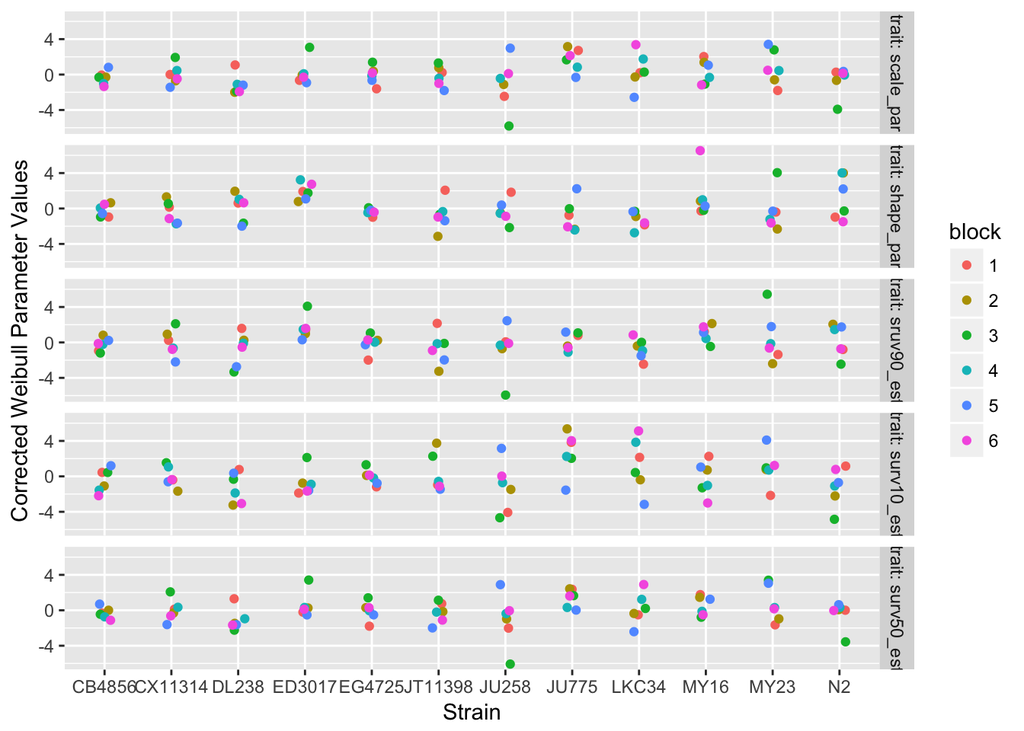

The correction for block effect makes differences in strains more apparent, but they still appear to be small. I’ll run the heitability test on these corrected traits.

#### Calculate heritability for corrected traits

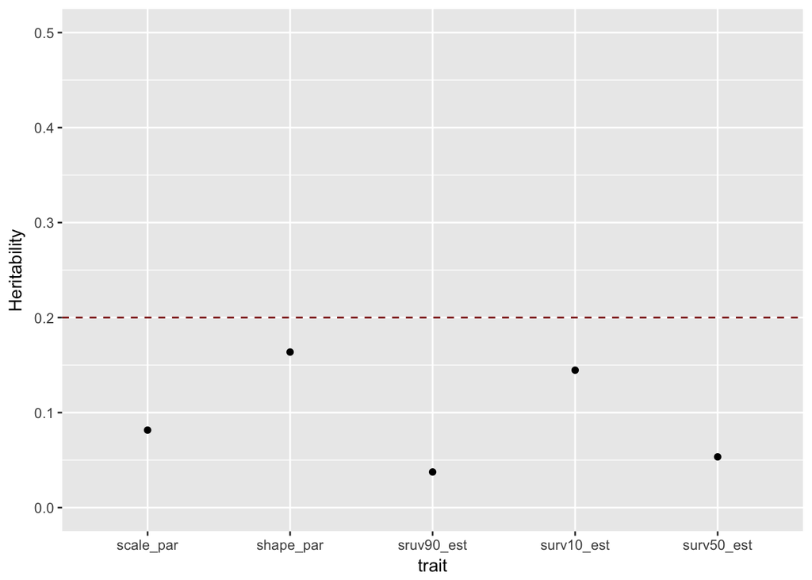

Correcting for block effect increases the heritability estimates for all traits but they are still low for GWA, i.e. < 0.2. We could improve heritability by ensuring that all strains are treated equally before and during assays. Some things to try…  
1) Equal number of generations prior to assay start  
2) Avoid starvation or population bottlenecking in generations leading up to assay  
3) Ensuring that food supply is consistant across WorMotels  
4) WormMotels should be filled with agar and food at a similar time prior to assay start  
5) Control humidity and temperature across all assays